# Project Wrangle and Analyze Data: Act Report

### *Author: Anthony T. O'Brien M.D.*

##### 12th May 2018

# Introduction

My analysis focused on various parts of the wrangled dataframe. Specifically, I looked at the relationship between the number of favorites relative to the number of retweets, the impact that a dog's score would have on the aformentioned relationship, a quick count of the most popular methods to post these tweets (including a quick review of the most popular dog breed), and finally a review of the scoring pattern over the time period in which the data were collected.

# Methods

To study the relationship between the number of favorited tweets relative to the number of retweets, I used a scatterplot wiht a regression line superimposed.

Once the scatterplot was created I continued with a bubble plot which adds a third variable to give an extra dimension to the plot, this variable was the score_ratio divided by 18.

Finally as a continuation of the score analysis, I plotted the score ratio relative to the time the score was tweeted.

```python
from IPython.display import HTML

HTML('''<script>
code_show=true;
function code_toggle() {
 if (code_show){
 $('div.input').hide();
 } else {
 $('div.input').show();
 }
 code_show = !code_show
}
$( document ).ready(code_toggle);
</script>
<form action="javascript:code_toggle()"><input type="submit" value="Click here to toggle on/off the raw code."></form>''')
```

# Results

Graph 1 plots the relationship between the number of tweets and retweets in a scatterplot with a superimposed linear regression.

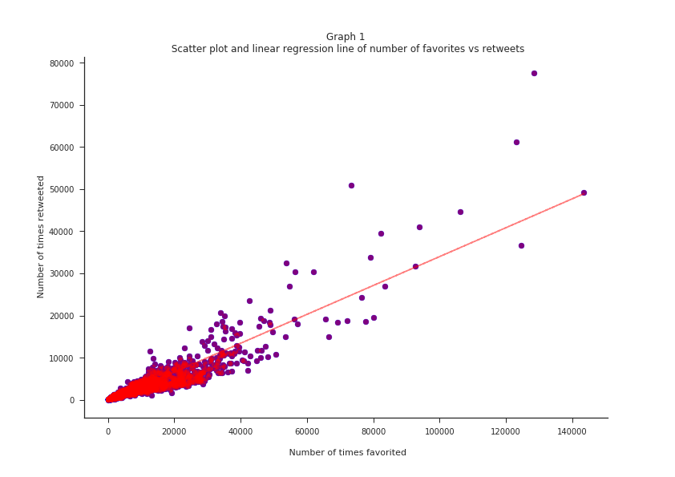

```python
from IPython.display import Image
Image("Img/graph1.png")
```

Graph 2 builds on graph 1 by adding a density variable to the z axis (i.e. score ratio/18).

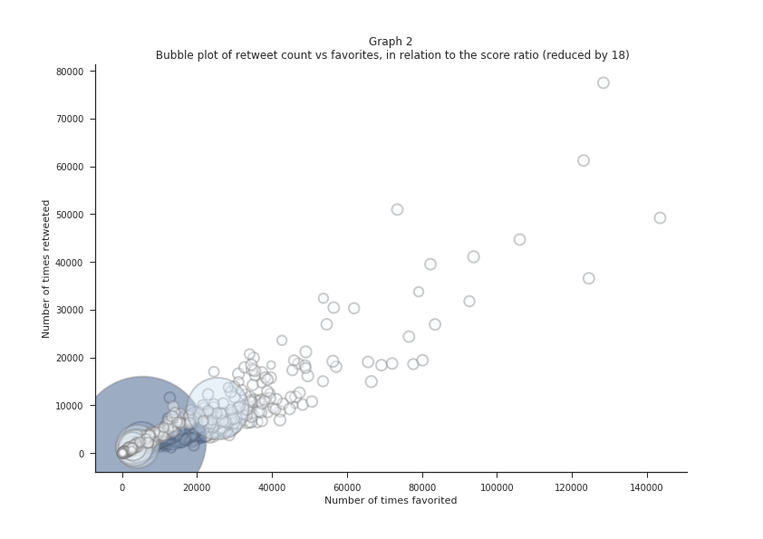

```python
from IPython.display import Image
Image("Img/graph2.png")
```

Graph 3 plots a bargraph of the method for publishing tweets (i.e. iPhone, Webclient, or tweetdeck).

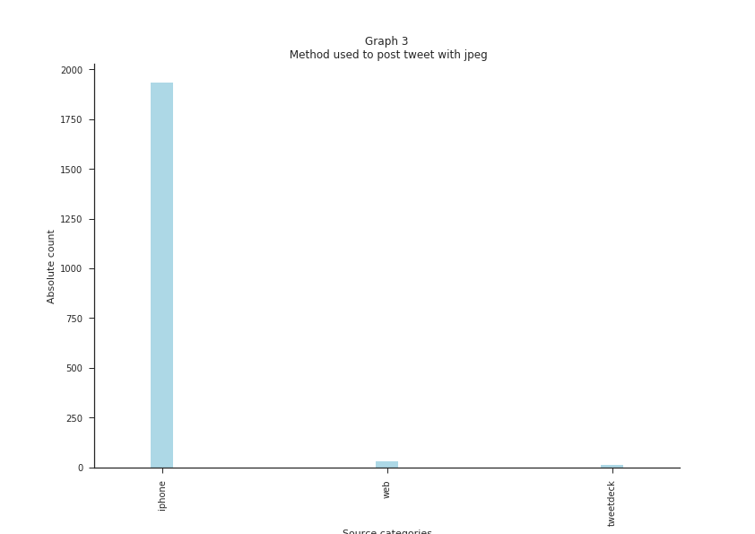

```python
from IPython.display import Image
Image("Img/graph3.png")
```

Graph 4 studies the reltionship between the dog's score_ratio over the period of time in which the data was collected

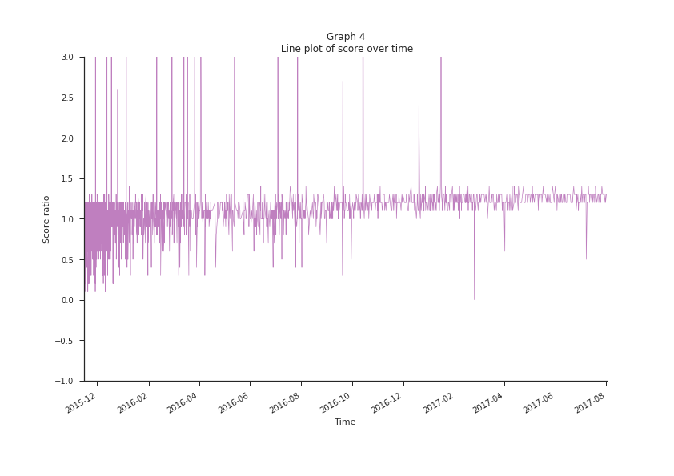

```python
from IPython.display import Image
Image("Img/graph4.png")
```

# Analysis

What we learn from these results is the following:

Relationship between favorites and retweets

- 1) There is a linear relationship between the number of favorited tweets vs the number of retweets, although this relationship becomes less obvious over 30,000 favorites.

Method of tweeting

- 4) The iphone was the most preferred method for perfoming tweets in this data set, followed by WebClient and lastly tweetdeck